### Question 1

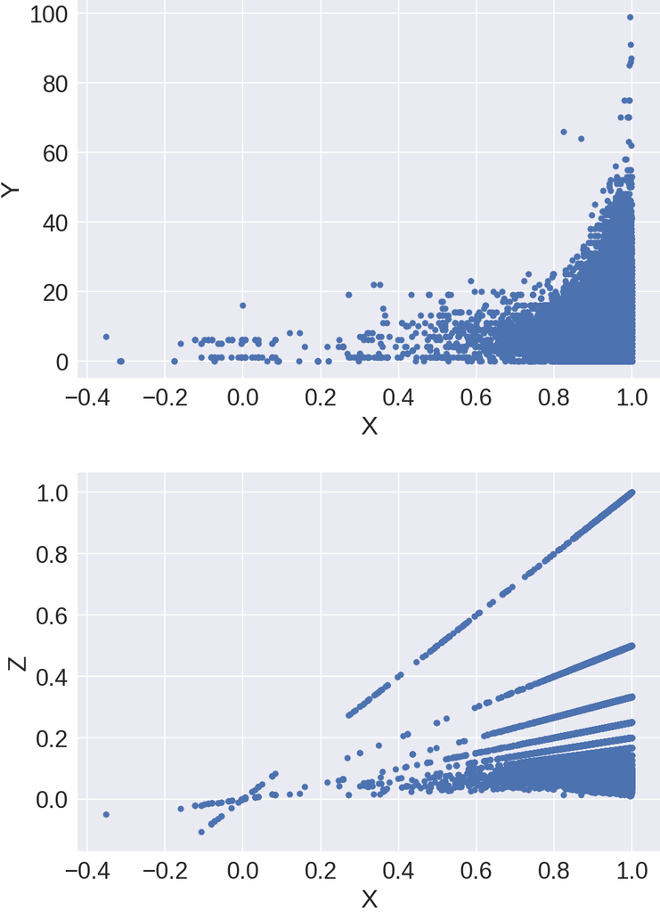

On the top figure you see a scatter plot for variables X and Y. Variable Z is a function of X and Y and on the bottom figure a scatter plot between X and Z is shown. Can you recover Z as a function of X and Y?

### Question 2

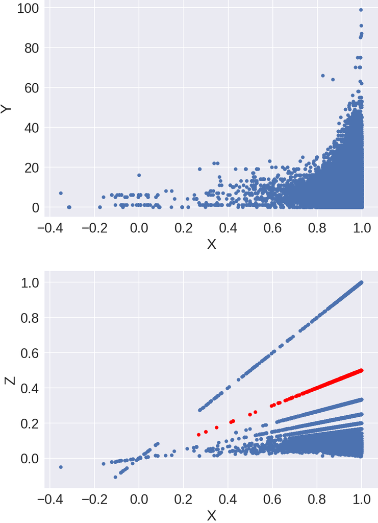

What Y value do the objects colored in red have?

Enter answer here:

### Question 3

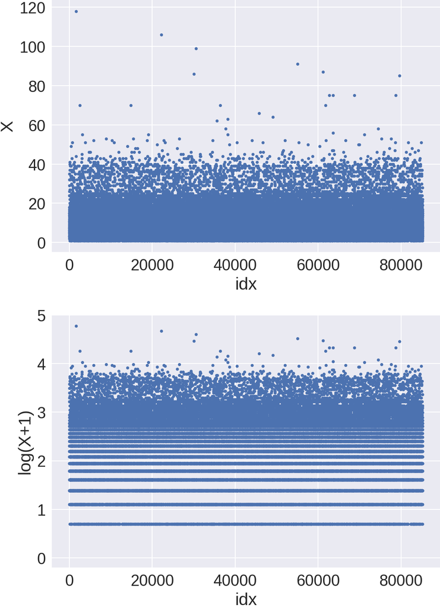

The following code was used to produce these two plots:

```
# top plot
plt.plot(x, '.')

# bottom plot
logX = np.log1p(x) # no NaNs after this operation
plt.plot(logX, '.')
```

Which hypotheses about variable X do NOT contradict with the plots?

2<=X<3 happens more frequently than 3<=X<4  
X can take a value of zero  
X is a counter or label encoded categorical feature  
X can be the temperature (in Celsius) in different cities at different times  
X takes only discrete values

### Question 4

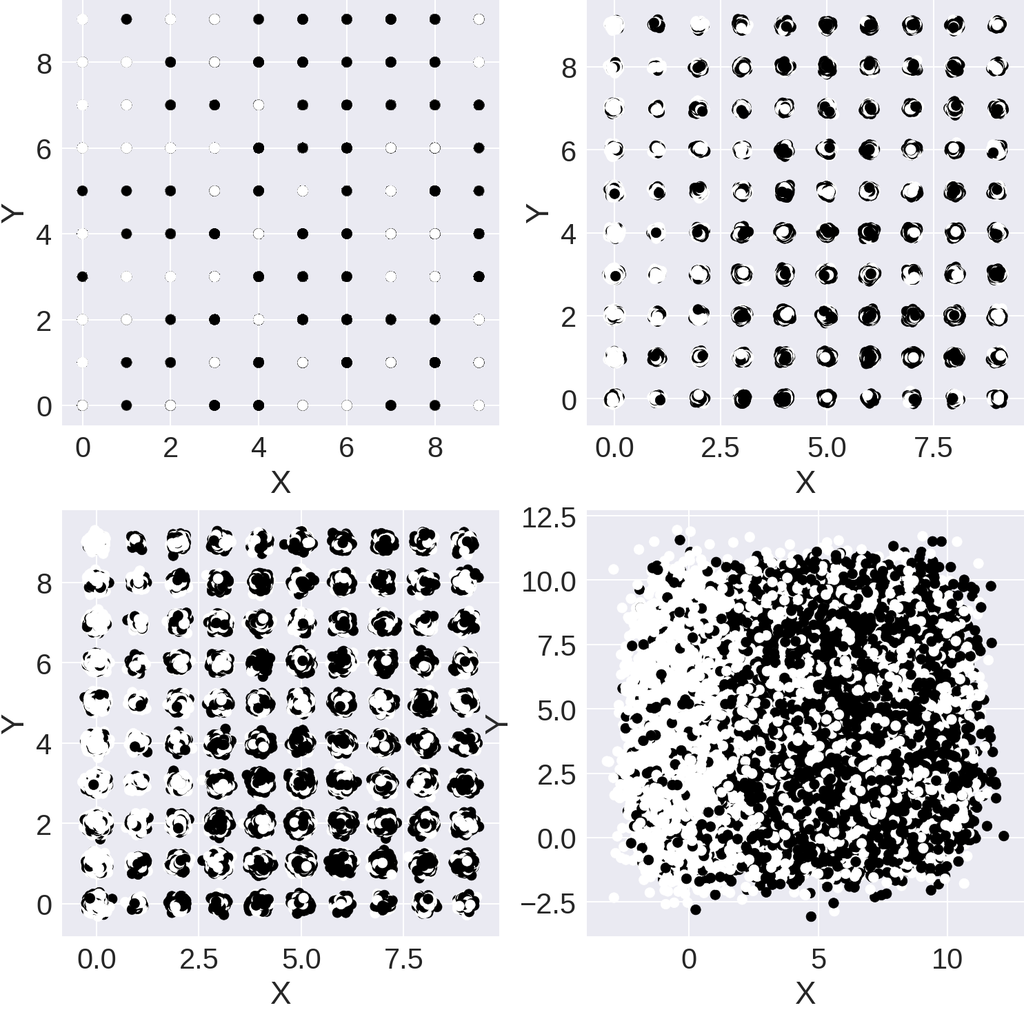

Top left plot shows X vs Y scatter plot, produced with the following code

```
# y is a target vector
plt.scatter(X, Y, c = y)
```

Other plots were produced by *jittering* X and Y values:

[output not shown]

That is, we add Gaussian noise to the features before drawing scatter plot. Which statements are correct?

Standard deviation for Jittering is the largest on the bottom right plot.  
Top right plot is "better" than top left one: every piece of information we can find on the top left we can also find on the top right, but not vice versa.  
We need to jitter variables not only for a sake of visualization, but also because it is beneficial for a model.  
Target is completely determined by coordinates (x,y), i.e. the label of the point is *completely determined* with it's position (x,y). Saying the same again: if we only have two features (x,y), we can build a classifier, that is accurate 100% times  
It is *always* beneficial to jitter variables before building a scatter plot